# Regression and report generation

Niels Richard Hansen

February 4, 2016

# A practical exercise on using knitr

Solve this exercise using Markdown and knitr. Use [the code](https://nielsrhansen.github.io/courses/regression2016/Exercises/SAT.Rmd) that generated this document as a template.

From RStudio just click on ‘Knit HTML’ to get the result. Alternatively, you can run the following code.

```r
library(knitr)
library(markdown)
knit("SAT.Rmd")   ### Creates the Markdown file
markdownToHTML("SAT.md", "SAT.html") ### Creates the html file
browseURL(paste('file://', file.path(getwd(), 'SAT.html'), sep=''))
```

You can also read more about [using R and Markdown with RStudio](http://rmarkdown.rstudio.com).

The data set to consider in this exercise consists of mean verbal SAT scores for each of the 50 US states together with the percentage of students taking the test.

To help you get started we read in the data and construct a plot.

```r
sat <- read.table(
  "https://nielsrhansen.github.io/courses/regression2016/Data/SAT.txt",
  header = TRUE)
```

```r
library(tidyverse)
```

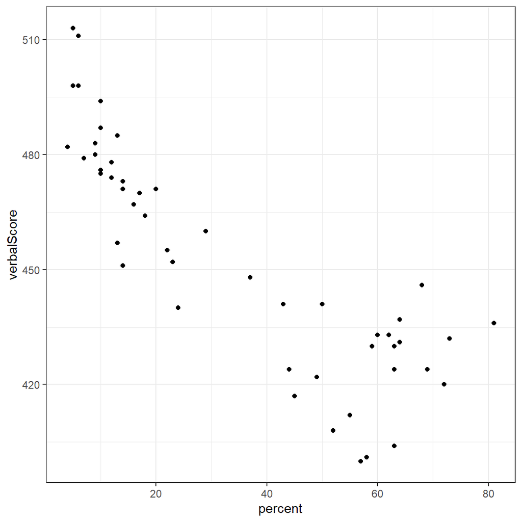

```r
library(conflicted)
theme_set(theme_bw()) ## My choice of theme over the default.
qplot(percent, verbalScore, data = sat)
```

## Question 1

*Fit a linear regression model with an intercept of the state SAT score as a function of percentage of students. Add the fitted line to the plot.*

Let us take a short look at the data:

```r
sat %>% head()
```

```
##   percent verbalScore
## 1       4         482
## 2       5         498
## 3       5         513
## 4       6         498
## 5       6         511
## 6       7         479
```

```r
sat %>% summary()
```

```
##     percent       verbalScore
##  Min.   : 4.00   Min.   :400.0
##  1st Qu.:12.00   1st Qu.:430.2
##  Median :23.50   Median :451.5
##  Mean   :34.06   Mean   :452.8
##  3rd Qu.:58.75   3rd Qu.:475.8
##  Max.   :81.00   Max.   :513.0
```

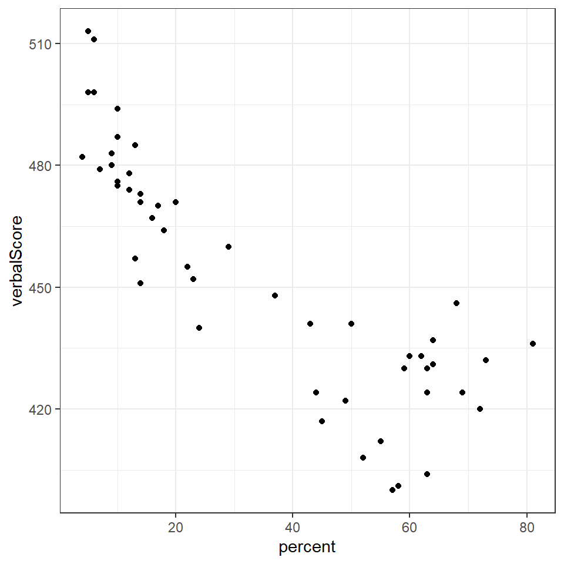

```r
(p_sat <- ggplot(sat, mapping = aes(x = percent, y = verbalScore)) + geom_point())
```

We make the basic linear model

```r
lm_basic <- lm(verbalScore ~ percent, data = sat)
```

We can also look at the result of the model

```r
summary(lm_basic)
```

```
##
## Call:
## lm(formula = verbalScore ~ percent, data = sat)
##
## Residuals:
##     Min      1Q  Median      3Q     Max
## -28.989  -9.043   0.395   8.755  31.880
##
## Coefficients:
##              Estimate Std. Error t value Pr(>|t|)
## (Intercept) 488.05330    3.75601  129.94  < 2e-16 ***
## percent      -1.03621    0.08975  -11.54 1.87e-15 ***
## ---
## Signif. codes:  0 '***' 0.001 '**' 0.01 '*' 0.05 '.' 0.1 ' ' 1
##
## Residual standard error: 15.43 on 48 degrees of freedom
## Multiple R-squared:  0.7352, Adjusted R-squared:  0.7297
## F-statistic: 133.3 on 1 and 48 DF,  p-value: 1.868e-15
```

We can plot the model as well, either directly from this model that we have just built, or via `ggplot`

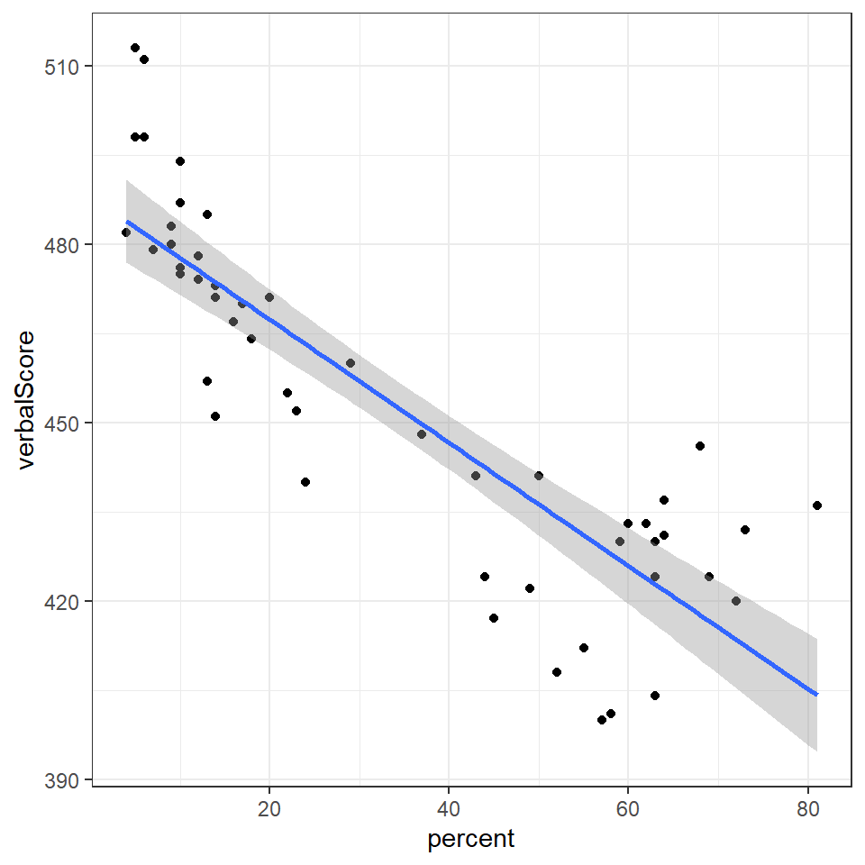

```r
p_sat + geom_smooth(method = "lm")
```